# Regional Analysis

Melia Waring

9/15/2020

```
## 'data.frame':    29678 obs. of  10 variables:
##  $ STATION: Factor w/ 1 level "USW00022521": 1 1 1 1 1 1 1 1 1 1 ...
##  $ NAME   : Factor w/ 1 level "HONOLULU INTERNATIONAL AIRPORT, HI US": 1 1 1 1 1 1 1 1 1 1 ...
##  $ DATE   : Factor w/ 29678 levels "1939-06-01","1939-06-02",..: 1 2 3 4 5 6 7 8 9 10 ...
##  $ PRCP   : num  NA NA NA NA NA NA NA NA NA NA ...
##  $ SNOW   : num  NA NA NA NA NA NA NA NA NA NA ...
##  $ SNWD   : num  NA NA NA NA NA NA NA NA NA NA ...
##  $ TAVG   : num  26.2 25.4 25.6 26.1 25.2 25.1 26.1 26.3 25.7 25.6 ...
##  $ TMAX   : num  NA NA NA NA NA NA NA NA NA NA ...
##  $ TMIN   : num  NA NA NA NA NA NA NA NA NA NA ...
##  $ TOBS   : num  NA NA NA NA NA NA NA NA NA NA ...
```

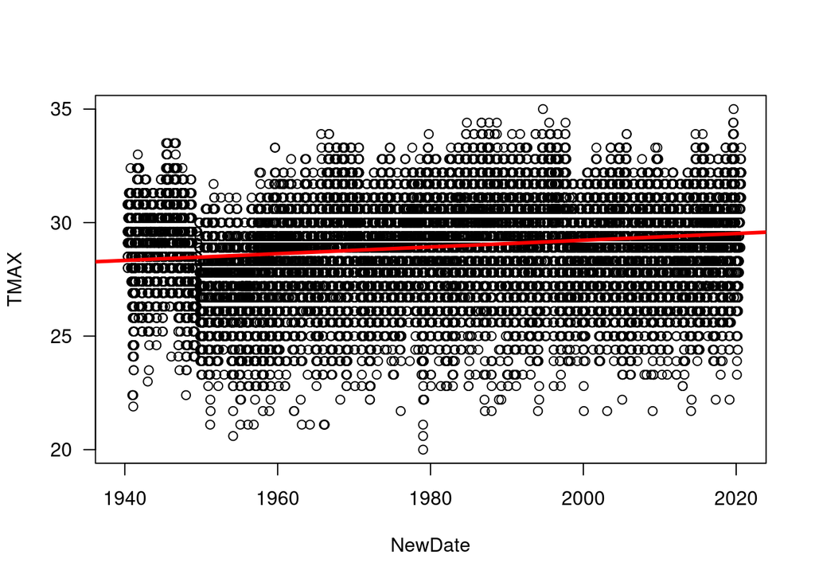

```r
(TMAX.lm.sum = summary(lm(TMAX ~ NewDate, data=climate_data)))
```

```
##
## Call:
## lm(formula = TMAX ~ NewDate, data = climate_data)
##
## Residuals:
##     Min      1Q  Median      3Q     Max
## -8.9128 -1.5129  0.1077  1.6601  5.8549
##
## Coefficients:
##              Estimate Std. Error t value Pr(>|t|)
## (Intercept) 2.878e+01  1.383e-02 2081.09   <2e-16 ***
## NewDate     4.056e-05  1.488e-06   27.26   <2e-16 ***
## ---
## Signif. codes:  0 '***' 0.001 '**' 0.01 '*' 0.05 '.' 0.1 ' ' 1
##
## Residual standard error: 2.087 on 28544 degrees of freedom
##   (1132 observations deleted due to missingness)
## Multiple R-squared:  0.02538,    Adjusted R-squared:  0.02534
## F-statistic: 743.2 on 1 and 28544 DF,  p-value: < 2.2e-16
```

### Interpreting the Results:

These results are stated for the graph that displays maximum daily temperature in Honolulu, Hawaii. We reject the null hypothesis because the events that this might occur by chance is small: p < 2e-16 for the slope and p < 2e-16 for the y intercept is 0. In addition, the r^2 value is 0.025. This means that 2.5% of the variation can be explained by the independent variable (the date).

```
## 'data.frame':    957 obs. of  5 variables:
##  $ Month: chr  "05" "06" "07" "08" ...
##  $ Year : chr  "1940" "1940" "1940" "1940" ...
##  $ TMAX : num  29.2 29.6 30.2 30.1 30.2 ...
##  $ YEAR : num  1940 1940 1940 1940 1940 ...
##  $ MONTH: num  5 6 7 8 9 10 11 12 1 2 ...
```

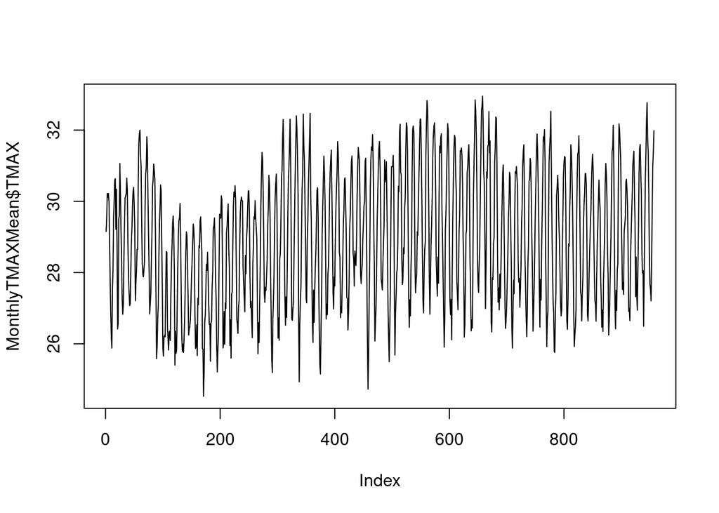

```
##
## Call:
## lm(formula = TMAX ~ YEAR, data = MonthlyTMAXMean[MonthlyTMAXMean$Month ==
##     "05", ])
##
## Residuals:
##      Min       1Q   Median       3Q      Max
## -1.99731 -0.53433  0.01695  0.55872  1.97108
##
## Coefficients:
##              Estimate Std. Error t value Pr(>|t|)
## (Intercept) -0.878731   8.068664  -0.109 0.913553
## YEAR         0.015110   0.004075   3.708 0.000386 ***
## ---
## Signif. codes:  0 '***' 0.001 '**' 0.01 '*' 0.05 '.' 0.1 ' ' 1
##
## Residual standard error: 0.8575 on 79 degrees of freedom
## Multiple R-squared:  0.1483, Adjusted R-squared:  0.1375
## F-statistic: 13.75 on 1 and 79 DF,  p-value: 0.0003861
```

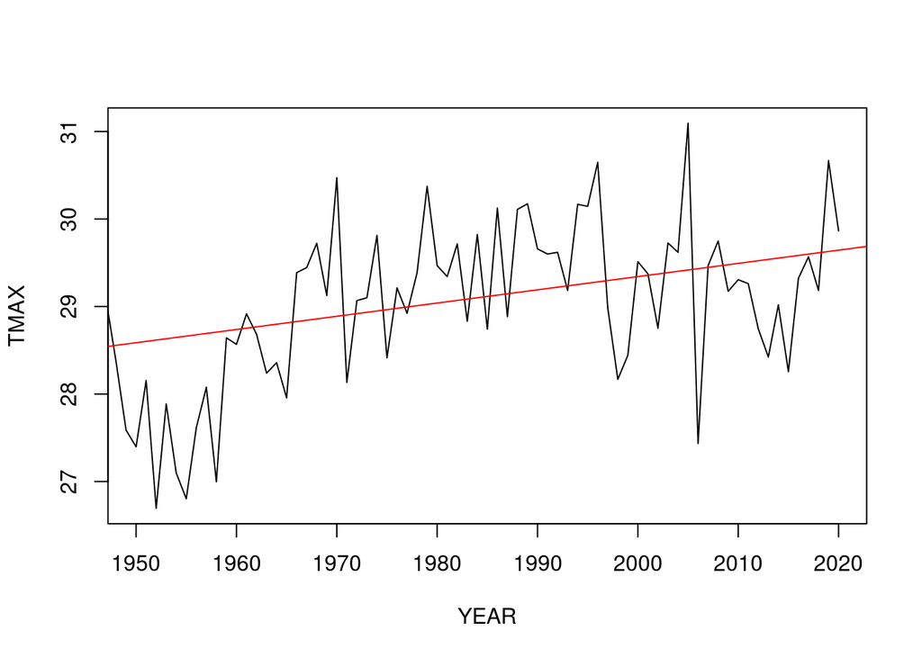

```r
MonthlyTMINMean = aggregate(TMIN ~ Month + Year, climate_data, mean)
MonthlyTMINMean$YEAR = as.numeric(MonthlyTMINMean$Year)

     # Fixing the Format of Month and Year as numeric
MonthlyTMINMean$YEAR = as.numeric(MonthlyTMINMean$Year)
MonthlyTMINMean$MONTH = as.numeric(MonthlyTMINMean$Month)
head(MonthlyTMINMean)
```

```
##   Month Year     TMIN YEAR MONTH
## 1    05 1940 21.59286 1940     5
## 2    06 1940 22.69310 1940     6
## 3    07 1940 23.45714 1940     7
## 4    08 1940 24.21034 1940     8
## 5    09 1940 23.05333 1940     9
## 6    10 1940 22.87143 1940    10
```

```r
# First I create a vector of months
Months = c("January", "February", "March", "April",
    "May", "June", "July", "August", "September", "October",
    "November", "December")

# Creating a panel so I can see all the figures at once

par(mfrow = c(4, 3), mar = c(5, 4, 3, 2) + 0.1)
TMAXresult <- NA
for (i in 1:12)
  plot(TMAX ~ YEAR, data = MonthlyTMAXMean[MonthlyTMAXMean$MONTH == i, ], ty = "l", las = 1, xlim = c(1940, 2020), main = Months[i])
  Month.lm <- lm(TMAX ~ YEAR, data = MonthlyTMAXMean[MonthlyTMAXMean$MONTH == i, ])
  summary(Month.lm)
```

```
##
## Call:
## lm(formula = TMAX ~ YEAR, data = MonthlyTMAXMean[MonthlyTMAXMean$MONTH ==
##     i, ])
##
## Residuals:
##      Min       1Q   Median       3Q      Max
## -1.67402 -0.66896  0.00989  0.49711  2.98833
##
## Coefficients:
##             Estimate Std. Error t value Pr(>|t|)
## (Intercept) 6.863551   8.407808   0.816   0.4168
## YEAR        0.010340   0.004247   2.435   0.0172 *
## ---
## Signif. codes:  0 '***' 0.001 '**' 0.01 '*' 0.05 '.' 0.1 ' ' 1
##
## Residual standard error: 0.8772 on 78 degrees of freedom
## Multiple R-squared:  0.07063,    Adjusted R-squared:  0.05871
## F-statistic: 5.927 on 1 and 78 DF,  p-value: 0.01719
```

```r
  abline(coef(Month.lm), col = "red")
```

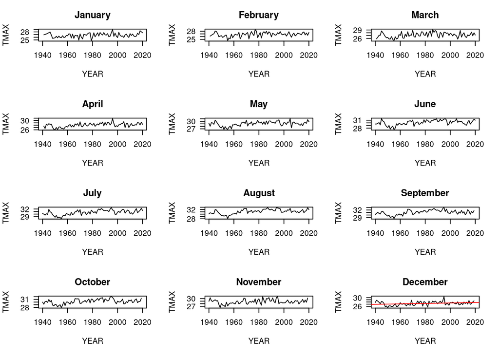

```r
  TMAXresult <- rbind(TMAXresult, cbind(Months[i], round(coef(Month.lm)[2], 4), round(summary(Month.lm)$coefficients[2,4], 4), round(summary(Month.lm)$r.squared, 3)))
```

### Interpreting the Results:

These results above are stated for the graph that displays the maximum temperature for December in Honolulu, Hawaii. The change is 0.0103 degrees C/year with a probability of 0.0172. We reject the null hypothesis because the events that this might occur by chance is small. In addition, the r^2 value is 0.0706. This means that 7.06% of the variation can be explained by the independent variable (the date).

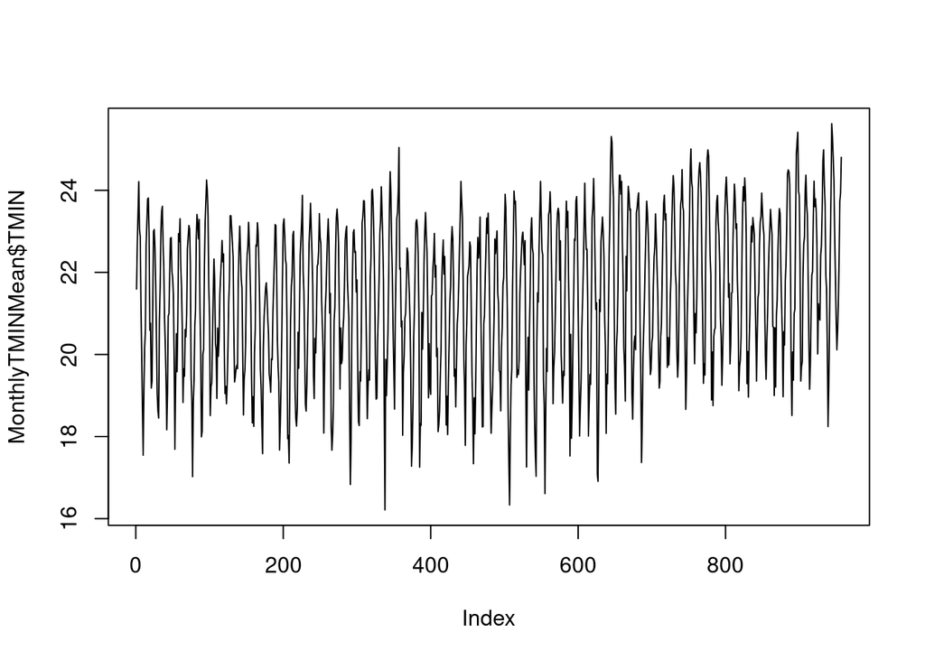

```r
plot(MonthlyTMINMean$TMIN, ty='l')
```

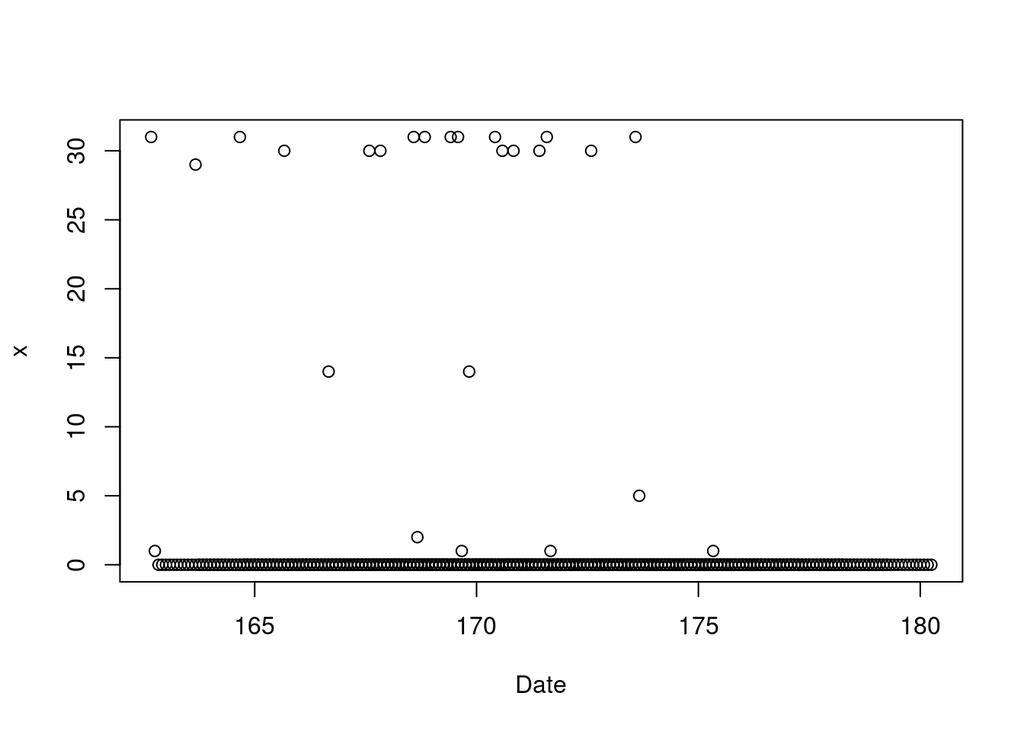

```r
# The aggregate command is used to create a simplified dataset. In this case, we are
# creating a sum of PCRP based on each month and year.

climate_data$PRCP[climate_data$PRCP==-9999] <- NA
Missing <- aggregate(is.na(climate_data$PRCP), list(climate_data$Month, climate_data$Year), sum)
Missing$Date = as.numeric(Missing$Group.1) + as.numeric(Missing$Group.2)/12
plot(x ~ Date, data=Missing)
```

```r
MonthlyPRCPMean = aggregate( PRCP~ Month + Year, climate_data, sum)
```

```r
TotalPPT <- aggregate(climate_data$PRCP, list(climate_data$Month, climate_data$Year), sum, na.rm=T)
names(TotalPPT) = c("Group.1", "Group.2", "ppt")
NonMissing <- Missing[Missing$x < 5, c(1:3)]
library(dplyr)
PPT <- merge(TotalPPT, NonMissing, all.y=TRUE)
PPT$Date <- as.numeric(PPT$Group.1) + as.numeric(PPT$Group.2)/12
head(PPT)
```

```
##   Group.1 Group.2   ppt x     Date
## 1      01    1941  14.2 1 162.7500
## 2      01    1942   5.8 0 162.8333
## 3      01    1943 294.4 0 162.9167
## 4      01    1944   0.3 0 163.0000
## 5      01    1945   4.3 0 163.0833
## 6      01    1946 179.8 0 163.1667
```

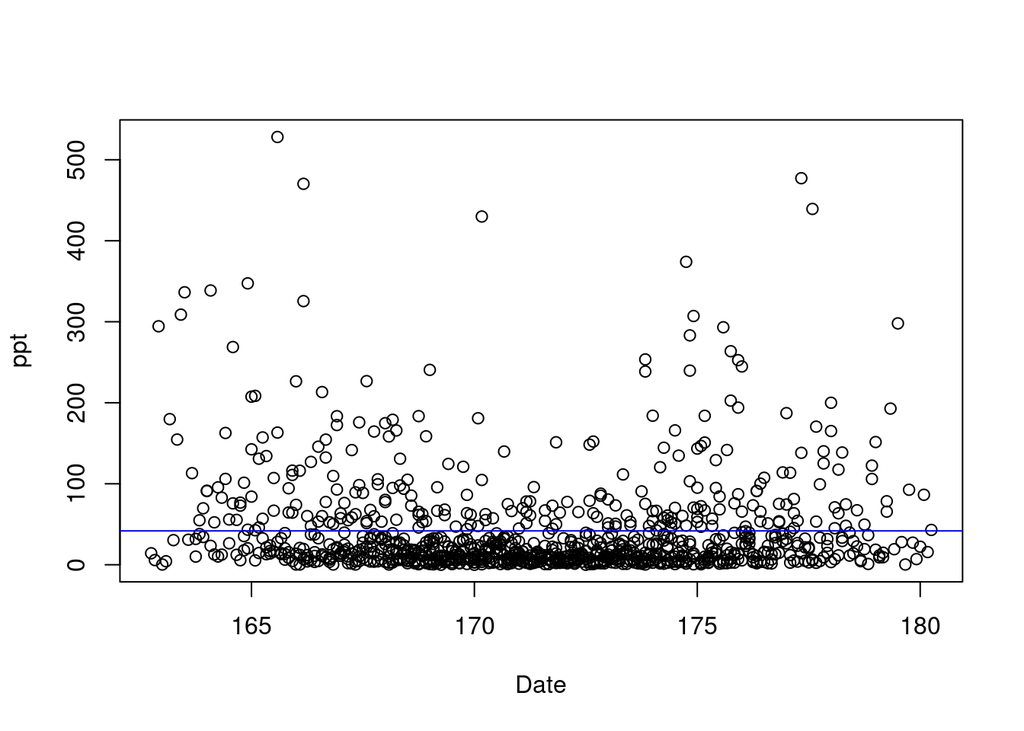

```r
PRCP_mean = mean(PPT$ppt)
plot(ppt~Date, data=PPT)
abline(h=PRCP_mean, col="blue")
```

```r
MonthlyPRCPMean = aggregate( PRCP~ Month + Year, climate_data, sum)
str(MonthlyPRCPMean)
```

```
## 'data.frame':    958 obs. of  3 variables:
##  $ Month: chr  "05" "06" "07" "08" ...
##  $ Year : chr  "1940" "1940" "1940" "1940" ...
##  $ PRCP : num  14.3 14.5 17.5 10.6 11.6 ...
```

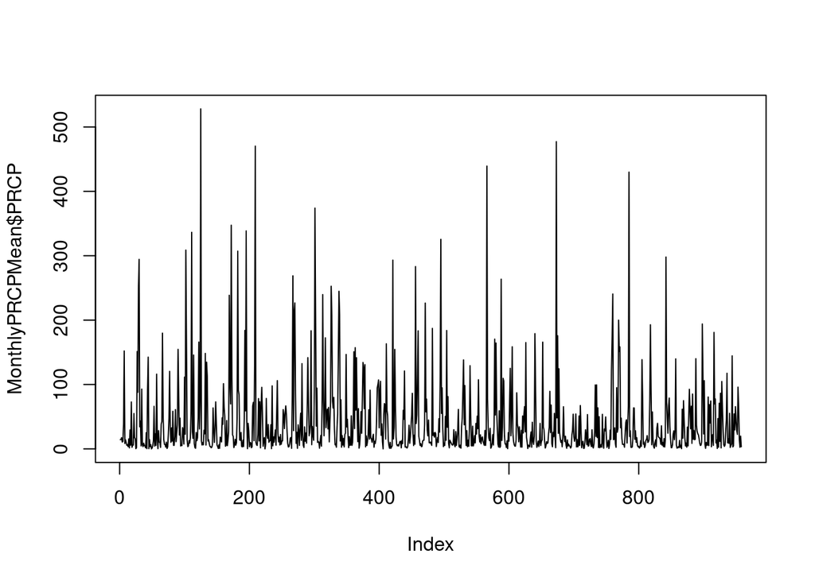

```r
plot(MonthlyPRCPMean$PRCP, ty='l')
```